# Real-world Data Wrangling

## Introduction:

This project endeavors to compile a dataset tailored for Natural Language Processing (NLP) tasks, specifically targeting the named entity disambiguation problem. It aims to gather a diverse array of named entities categorized as persons, locations, and organizations, supplemented with both context and definition. Definitions are sourced from Wikidata, while contextual information is extracted from Wikipedia. Only entities endowed with both context and description are included in the dataset, ensuring relevance and richness for downstream NLP tasks.

## 1. Gather data

In this section, you will extract data using there different data gathering methods and combine the data. the first gathering model is manaul, the second is programmatically using sparql query, and finaly, using Python library.

### **1.1.** Problem Statement

This project aims to collect a dataset for NLP tasks, such as named entity disambiguation problem. We have a group of named entities categorized as persons, locations, and organizations. For each named entity, we seek to collect both a context and a definition. Definitions will be sourced from Wikidata, and context will be gathered from Wikipedia. Entities that have both context and description will be labeled with a value of 1.

### Dataset 1

**Type:** Excel file with multiple sheets.

I selected this dataset because it offers a varied collection of named entities, encompassing individuals, organizations, and geographic locations. Its inclusivity ensures relevance across a spectrum of Natural Language Processing (NLP) tasks. Moreover, its interchangeability with other datasets containing named entities underscores the flexibility of our methodology, facilitating seamless adaptation to diverse research objectives and domains within NLP.

**Methodology:** The dataset was gathered manually from different web resources for named entities of types (person, location, and organization). These named entities are from the Palestinian community.

**Dataset variables:**

| Variable Name | Description |
| --- | --- |
| `Name_en1` | Name of the person (e.g., 'Hafez Hamdan') |
| `Name_en` | Name of the organization (e.g., 'Birzeit org') |
| `Lname_en1` | Name of the location (e.g., 'Jerusalem', 'New York') |

### Dataset 2

**Type:** Excel File

**Methodology:** The dataset was gathered from Wikidata using a SPARQL query to collect information for named entities from dataset 1 that exist in the Wikidata knowledge graph.

I seletected Wikidata as a source of data, as it already conatins the needed information as a knowledge graph for named entities and the nodes are connected with many knowledge bases suh as Wikipedia.

**Dataset variables:**

| Column Name | Description |
| --- | --- |
| `item.type` | Type of the Wikidata item. |
| `item` | Item ID of the Wikidata entity. |
| `itemLabel.xml:lang` | XML language of the item label. |
| `itemLabel.type` | Type of the item label. |
| `itemLabel` | Label of the Wikidata entity in the specified language. |
| `itemDescription.xml:lang` | XML language of the item description. |
| `itemDescription.type` | Type of the item description. |
| `itemDescription` | Description of the Wikidata entity in the specified language. |
| `entity_type.type` | Type of the entity. |
| `entity_type` | Type of the Wikidata entity. |
| `main_category` | Main category associated with the item, if available. |
| `altLabel_list.type` | Type of the alternative label list. |
| `altLabel_list` | Comma-separated list of alternative labels for the item, if available. |
| `article.type` | Type of the Wikipedia article. |
| `article` | URL of the Wikipedia article associated with the item. |
| `wikipediaLabel.xml:lang` | XML language of the Wikipedia label. |
| `wikipediaLabel.type` | Type of the Wikipedia label. |
| `wikipediaLabel` | Label of the Wikipedia article in the specified language. |
| `entity_type_list.type` | Type of the entity type list. |
| `entity_type_list` | Comma-separated list of entity types associated with the item. |

### Dataset 3

**Type:** Excel File.

**Dataset variables:**

| Column Name | Description |
| --- | --- |
| `item` | Item ID of the Wikidata entity. |
| `itemLabel` | Label of the Wikidata entity. |
| `itemDescription` | Description of the Wikidata entity. |
| `entity_type` | Type of the Wikidata entity. |
| `main_category` | Main category associated with the item, if available. |
| `altLabel_list` | Comma-separated list of alternative labels for the item. |
| `article` | URL of the Wikipedia article associated with the item. |
| `wikipediaLabel` | Label of the Wikipedia article associated with the item. |
| `entity_type_list` | Comma-separated list of entity types associated with the item. |
| `FirstTwoSentences` | First two sentences of the Wikipedia description. |

## Gathering Methods for the combined dataset (after merging)

## Querying a SPARQL endpoint (knowledge graph) in python Form Awraq DataSheet Named Entitiy Labels.

[figure not shown]

# Phase 1: Dataset 2: Wikidata Scraper

## 1.0 Necessary imports

Note you will need to install (e.g. pip install) pandas (which should have come with Anaconda) and SPARQLWrapper on your machine before this will work

```python
!pip install -qq -U watermark
!pip install -qq google-play-scraper
!pip install SPARQLWrapper
!pip install WordCloud
```

```python
import os
from SPARQLWrapper import JSON, SPARQLWrapper
import pandas as pd
import json
import matplotlib.pyplot as plt
from pandas import json_normalize
from tqdm import tqdm
import numpy as np
```

```python
%reload_ext watermark
%watermark -v -p pandas,matplotlib,seaborn,google_play_scraper,SPARQLWrapper
```

```
Python implementation: CPython
Python version       : 3.11.7
IPython version      : 8.20.0

pandas             : 2.2.2
matplotlib         : 3.8.0
seaborn            : 0.12.2
google_play_scraper: 1.2.6
SPARQLWrapper      : 2.0.0
```

## 1.1.0 SPARQL ENDPOINT

### 1.1.1 Create query function

The function below takes a SPARQL query string, queries a sparql service, and returns the result as a pandas DataFrame (a table). [Try it on Wikidata Query service](https://w.wiki/49i8)

```python
def query_wikidata(sparql_query, sparql_service_url):
    print(sparql_query)
    """
    Query the endpoint with the given query string and return the results as a pandas Dataframe.
    """
    # create the connection to the endpoint
    # Wikidata enforces now a strict User-Agent policy, we need to specify the agent
    # See here https://www.wikidata.org/wiki/Wikidata:Project_chat/Archive/2019/07#problems_with_query_API
    # https://meta.wikimedia.org/wiki/User-Agent_policy
    sparql = SPARQLWrapper(sparql_service_url, agent="Sparql Wrapper on Jupyter example")

    sparql.setQuery(sparql_query)
    sparql.setReturnFormat(JSON)

    # ask for the result
    result = sparql.query().convert()
    return json_normalize(result["results"]["bindings"])
```

### 1.1.2 Run our SPARQL query

```python
def search_wikidata_label_en(label, lang='en'):
    """
    Searches for entities in Wikidata that match a given label in a specified language.

    This function constructs and sends a SPARQL query to the Wikidata Query Service to find entities
    matching the provided label. The query retrieves various details about the entities including
    their descriptions, types, alternative labels, main categories, and corresponding Wikipedia articles.

    Args:
        label (str): The label to search for in Wikidata.
        lang (str): The language code for the search and the returned labels (default is 'en' for English).

    Returns:
        pandas.DataFrame: A DataFrame containing the search results with columns for article URL,
                          item ID, item label, item description, entity types, main category,
                          Wikipedia label, and alternative labels.

    Example:
        >>> search_wikidata_label_en("Albert Einstein")
        # Returns a DataFrame with information about entities related to "Albert Einstein"
    """
    sparql_query = (
        'SELECT DISTINCT ?article ?item ?itemLabel ?itemDescription '
        '(GROUP_CONCAT(DISTINCT(?entity_type); separator = ", ") AS ?entity_type_list) '
        '?main_category ?wikipediaLabel '
        '(GROUP_CONCAT(DISTINCT(?altLabel); separator = ", ") AS ?altLabel_list) WHERE {'
        'SERVICE wikibase:mwapi {'
        'bd:serviceParam wikibase:api "EntitySearch". '
        'bd:serviceParam wikibase:endpoint "www.wikidata.org".'
        f'bd:serviceParam mwapi:search "{label}".'
        f'bd:serviceParam mwapi:language "{lang}" .'
        '?item wikibase:apiOutputItem mwapi:item .'
        '?num wikibase:apiOrdinal true .}'
        '?item wdt:P31 ?entity_type .'
        'MINUS { ?item wdt:P31 wd:Q4167410}'
        'OPTIONAL { ?item wdt:P910 ?main_category}'
        'OPTIONAL { ?item skos:altLabel ?altLabel .}'
        'OPTIONAL { ?article schema:about ?item; schema:isPartOf <https://en.wikipedia.org/>; schema:name ?wikipediaLabel}'
        'SERVICE wikibase:label {'
        f'bd:serviceParam wikibase:language "{lang}" .'
        '}'
        '}'
        'GROUP BY ?article ?item ?itemLabel ?itemDescription ?main_category ?wikipediaLabel'
    )

    # URL for the Wikidata Query Service
    sparql_service_url = "https://query.wikidata.org/sparql"

    # Execute the query using a helper function (assumed to be defined elsewhere)
    result_table = query_wikidata(sparql_query, sparql_service_url)

    return result_table
```

```python
def search_wikidata_altlabel_en(label, lang='en'):
    sparql_query = (
        'SELECT DISTINCT ?article ?item ?itemLabel ?itemDescription (GROUP_CONCAT(DISTINCT(?entity_type); separator = ", ") AS ?entity_type_list) ?main_category ?wikipediaLabel (GROUP_CONCAT(DISTINCT(?altLabel); separator = ", ") AS ?altLabel_list) WHERE {'
        f'?item ?altLabel "{label}"@en.'

        'MINUS { ?item wdt:P31 wd:Q4167410}'

        'OPTIONAL { ?article schema:about ?item;'
        'schema:isPartOf <https://en.wikipedia.org/>;'
        'schema:name ?wikipediaLabel}'
        'OPTIONAL { ?item skos:altLabel ?altLabel .}'
        'SERVICE wikibase:label {'
        f'bd:serviceParam wikibase:language "{lang}" .'
        '}}'
        'GROUP BY ?article ?item ?itemLabel ?itemDescription ?main_category ?wikipediaLabel'
    )
    # to query another endpoint, change the URL for the service and the query
    sparql_service_url = "https://query.wikidata.org/sparql"
    result_table = query_wikidata(sparql_query, sparql_service_url)
    return result_table
```

### 1.1.3 Extract only the columns we care about

```python
COLMUNS_INCLUDED=['item.value', 'itemLabel.value', 'itemDescription.value', 'entity_type.value', 'main_category.value','altLabel_list.value']
def extract_needed_data(data_df):
  data_df =data_df[COLMUNS_INCLUDED]
  return data_df
```

## 1.1.4 Save The Dataframe into a Excel File

```python
def rename_columns(data_df):
    """
    Renames columns in a DataFrame by removing the ".value" suffix.

    This function renames columns in a DataFrame by removing the ".value" suffix from each column name.

    Args:
        data_df (pandas.DataFrame): The DataFrame whose columns are to be renamed.

    Returns:
        pandas.DataFrame: A DataFrame with columns renamed by removing the ".value" suffix.
    """
    # Renaming columns by removing the ".value" suffix
    data_df = data_df.rename(columns=lambda col: col.replace(".value", ""))

    return data_df
```

```python
def save_df_to_excel(df):
    """
    Saves a DataFrame to an Excel file after renaming its columns.

    This function renames columns in the input DataFrame by removing the ".value" suffix, then saves the DataFrame
    to an Excel file named 'wikidata_data_en.xlsx'.

    Args:
        df (pandas.DataFrame): The DataFrame to be saved to the Excel file.

    Returns:
        None
    """
    # Renaming columns
    df = rename_columns(df)

    # Checking if the DataFrame has rows
    if df.shape[0]:
        # Saving DataFrame to Excel file
        df.to_excel('wikidata_data_en.xlsx', index=False, header=True)
```

## 1.1.5.1 Read Dataset 1 Excel File

This function reads the mentioned Excel sheets

```python
# Set random seed for reproducibility
random_seed = 42
```

```python
def accumulate_data(df, clmn):
    """
    Accumulates data from a DataFrame by querying a SPARQL endpoint to fetch information about named entities.

    This function takes a DataFrame containing named entities in a specific column and iterates over each entity
    to query a SPARQL endpoint (knowledge graph) to fetch additional information about the entities. It accumulates
    the fetched data into a large DataFrame and returns it.

    Args:
        df (pandas.DataFrame): The DataFrame containing named entities.
        clmn (str): The name of the column in the DataFrame containing the named entities.

    Returns:
        pandas.DataFrame: A DataFrame containing accumulated data fetched from the SPARQL endpoint.
    """
    # Define columns for the large DataFrame
    DF_COLUMNS = ['item.type', 'item.value', 'itemLabel.xml:lang', 'itemLabel.type', 'itemLabel.value',
                  'itemDescription.xml:lang', 'itemDescription.type', 'itemDescription.value', 'entity_type.type',
                  'entity_type.value', 'main_category.type', 'main_category.value', 'altLabel_list.type',
                  'altLabel_list.value']

    # Initialize an empty DataFrame with the defined columns
    large_df = pd.DataFrame(columns=DF_COLUMNS)

    # Iterate over each named entity in the specified column
    for name in df[clmn]:
        # Query the SPARQL endpoint to fetch information about the named entity
        data_result = search_wikidata_label_en(name)
        print('From Label:', name, "---", data_result.shape[0])

        # Check if the search result contains data
        if data_result.shape[0] > 0:
            # Concatenate the fetched data with the large DataFrame
            large_df = pd.concat([large_df, data_result], ignore_index=True)
        # If the search result is empty, try searching using alternate labels
        elif data_result.shape[0] == 0:
            data_result = search_wikidata_altlabel_en(name)
            print('From Alternate Label:', name, "---", data_result.shape[0])

            # Check if the alternate label search result contains data
            if data_result.shape[0] > 0:
                # Concatenate the fetched data with the large DataFrame
                large_df = pd.concat([large_df, data_result], ignore_index=True)

    # Return the accumulated DataFrame
    return large_df
```

### 1.1.5.2 The Main function

This function loops through Named Entities, and combine the resuts into a large data frame

```python
SHEETS_INFO={
    'Person':['Name_en1'], # each entry represents Excel sheet name and a list of coulmns names
    'Org':['Name_en'],
    'Location':['Lname_en1']
}
```

```python
# difne a dataframe to hold the data from all sheets
df_all= pd.DataFrame()
# Iterate through the AWRAQ CSV file to read the data from the spesified sheets, coulmns names from the SHEETS_INFO disctionary
for sheet, COLUMNS  in tqdm(SHEETS_INFO.items()):
  print('sheet', sheet ,'COLUMNS', COLUMNS)
  df=pd.read_excel('awraq.xlsx',sheet)
  df.dropna()
  df = df.sample(n=300, random_state=random_seed)
  df.sort_values(COLUMNS[0])
  df.drop_duplicates(keep='first', inplace=True)
# define a new dataframe for the arabic labels for each sheet
  df_names =df[COLUMNS]
  print(COLUMNS[0])
# call search_wikidata method to get data and accumalate the data for each sheet in the big Dataframe
  df_all=accumulate_data(df_names,COLUMNS[0])
```

```
sheet Person COLUMNS ['Name_en1']
Name_en1
SELECT DISTINCT ?article ?item ?itemLabel ?itemDescription (GROUP_CONCAT(DISTINCT(?entity_type); separator = ", ") AS ?entity_type_list) ?main_category ?wikipediaLabel (GROUP_CONCAT(DISTINCT(?altLabel); separator = ", ") AS ?altLabel_list) WHERE {SERVICE wikibase:mwapi {bd:serviceParam wikibase:api …
From Label: Ahmed Hasan Abu Sharkh --- 0
SELECT DISTINCT ?article ?item ?itemLabel ?itemDescription (GROUP_CONCAT(DISTINCT(?entity_type); separator = ", ") AS ?entity_type_list) ?main_category ?wikipediaLabel (GROUP_CONCAT(DISTINCT(?altLabel); separator = ", ") AS ?altLabel_list) WHERE {?item ?altLabel "Ahmed Hasan Abu Sharkh"@en.MINUS { ?…
From Alternate Label: Ahmed Hasan Abu Sharkh --- 0
SELECT DISTINCT ?article ?item ?itemLabel ?itemDescription (GROUP_CONCAT(DISTINCT(?entity_type); separator = ", ") AS ?entity_type_list) ?main_category ?wikipediaLabel (GROUP_CONCAT(DISTINCT(?altLabel); separator = ", ") AS ?altLabel_list) WHERE {SERVICE wikibase:mwapi {bd:serviceParam wikibase:api …
From Label: Hafez Hamdan --- 0
SELECT DISTINCT ?article ?item ?itemLabel ?itemDescription (GROUP_CONCAT(DISTINCT(?entity_type); separator = ", ") AS ?entity_type_list) ?main_category ?wikipediaLabel (GROUP_CONCAT(DISTINCT(?altLabel); separator = ", ") AS ?altLabel_list) WHERE {?item ?altLabel "Hafez Hamdan"@en.MINUS { ?item wdt:P…
From Alternate Label: Hafez Hamdan --- 0
SELECT DISTINCT ?article ?item ?itemLabel ?itemDescription (GROUP_CONCAT(DISTINCT(?entity_type); separator = ", ") AS ?entity_type_list) ?main_category ?wikipediaLabel (GROUP_CONCAT(DISTINCT(?altLabel); separator = ", ") AS ?altLabel_list) WHERE {SERVICE wikibase:mwapi {bd:serviceParam wikibase:api …
From Label: Taher Al-Zubaidi --- 0
SELECT DISTINCT ?article ?item ?itemLabel ?itemDescription (GROUP_CONCAT(DISTINCT(?entity_type); separator = ", ") AS ?entity_type_list) ?main_category ?wikipediaLabel (GROUP_CONCAT(DISTINCT(?altLabel); separator = ", ") AS ?altLabel_list) WHERE {?item ?altLabel "Taher Al-Zubaidi"@en.MINUS { ?item w…
From Alternate Label: Taher Al-Zubaidi --- 0
SELECT DISTINCT ?article ?item ?itemLabel ?itemDescription (GROUP_CONCAT(DISTINCT(?entity_type); separator = ", ") AS ?entity_type_list) ?main_category ?wikipediaLabel (GROUP_CONCAT(DISTINCT(?altLabel); separator = ", ") AS ?altLabel_list) WHERE {SERVICE wikibase:mwapi {bd:serviceParam wikibase:api …
From Label: Christopher --- 50
SELECT DISTINCT ?article ?item ?itemLabel ?itemDescription (GROUP_CONCAT(DISTINCT(?entity_type); separator = ", ") AS ?entity_type_list) ?main_category ?wikipediaLabel (GROUP_CONCAT(DISTINCT(?altLabel); separator = ", ") AS ?altLabel_list) WHERE {SERVICE wikibase:mwapi {bd:serviceParam wikibase:api …
From Label: Hamdan Al-Saleh --- 0
SELECT DISTINCT ?article ?item ?itemLabel ?itemDescription (GROUP_CONCAT(DISTINCT(?entity_type); separator = ", ") AS ?entity_type_list) ?main_category ?wikipediaLabel (GROUP_CONCAT(DISTINCT(?altLabel); separator = ", ") AS ?altLabel_list) WHERE {?item ?altLabel "Hamdan Al-Saleh"@en.MINUS { ?item wd…
From Alternate Label: Hamdan Al-Saleh --- 0
SELECT DISTINCT ?article ?item ?itemLabel ?itemDescription (GROUP_CONCAT(DISTINCT(?entity_type); separator = ", ") AS ?entity_type_list) ?main_category ?wikipediaLabel (GROUP_CONCAT(DISTINCT(?altLabel); separator = ", ") AS ?altLabel_list) WHERE {SERVICE wikibase:mwapi {bd:serviceParam wikibase:api …
From Label: Mohamed Moussa Sammour --- 0
SELECT DISTINCT ?article ?item ?itemLabel ?itemDescription (GROUP_CONCAT(DISTINCT(?entity_type); separator = ", ") AS ?entity_type_list) ?main_category ?wikipediaLabel (GROUP_CONCAT(DISTINCT(?altLabel); separator = ", ") AS ?altLabel_list) WHERE {?item ?altLabel "Mohamed Moussa Sammour"@en.MINUS { ?…
From Alternate Label: Mohamed Moussa Sammour --- 0
SELECT DISTINCT ?article ?item ?itemLabel ?itemDescription (GROUP_CONCAT(DISTINCT(?entity_type); separator = ", ") AS ?entity_type_list) ?main_category ?wikipediaLabel (GROUP_CONCAT(DISTINCT(?altLabel); separator = ", ") AS ?altLabel_list) WHERE {SERVICE wikibase:mwapi {bd:serviceParam wikibase:api …
From Label: Salim Afandi Al-Qiblawi --- 0
```

[output cut: 1107 more lines]

```
From Alternate Label: Numan  Aqel --- 0
sheet Org COLUMNS ['Name_en']
Name_en
SELECT DISTINCT ?article ?item ?itemLabel ?itemDescription (GROUP_CONCAT(DISTINCT(?entity_type); separator = ", ") AS ?entity_type_list) ?main_category ?wikipediaLabel (GROUP_CONCAT(DISTINCT(?altLabel); separator = ", ") AS ?altLabel_list) WHERE {SERVICE wikibase:mwapi {bd:serviceParam wikibase:api …
From Label: Tulkarm Municipality --- 1
SELECT DISTINCT ?article ?item ?itemLabel ?itemDescription (GROUP_CONCAT(DISTINCT(?entity_type); separator = ", ") AS ?entity_type_list) ?main_category ?wikipediaLabel (GROUP_CONCAT(DISTINCT(?altLabel); separator = ", ") AS ?altLabel_list) WHERE {SERVICE wikibase:mwapi {bd:serviceParam wikibase:api …
From Label: Lebanese Ministry of National Education --- 0
SELECT DISTINCT ?article ?item ?itemLabel ?itemDescription (GROUP_CONCAT(DISTINCT(?entity_type); separator = ", ") AS ?entity_type_list) ?main_category ?wikipediaLabel (GROUP_CONCAT(DISTINCT(?altLabel); separator = ", ") AS ?altLabel_list) WHERE {?item ?altLabel "Lebanese Ministry of National Educat…
From Alternate Label: Lebanese Ministry of National Education --- 0
SELECT DISTINCT ?article ?item ?itemLabel ?itemDescription (GROUP_CONCAT(DISTINCT(?entity_type); separator = ", ") AS ?entity_type_list) ?main_category ?wikipediaLabel (GROUP_CONCAT(DISTINCT(?altLabel); separator = ", ") AS ?altLabel_list) WHERE {SERVICE wikibase:mwapi {bd:serviceParam wikibase:api …
From Label: Central Court in Nablus --- 0
SELECT DISTINCT ?article ?item ?itemLabel ?itemDescription (GROUP_CONCAT(DISTINCT(?entity_type); separator = ", ") AS ?entity_type_list) ?main_category ?wikipediaLabel (GROUP_CONCAT(DISTINCT(?altLabel); separator = ", ") AS ?altLabel_list) WHERE {?item ?altLabel "Central Court in Nablus"@en.MINUS { …
From Alternate Label: Central Court in Nablus --- 0
SELECT DISTINCT ?article ?item ?itemLabel ?itemDescription (GROUP_CONCAT(DISTINCT(?entity_type); separator = ", ") AS ?entity_type_list) ?main_category ?wikipediaLabel (GROUP_CONCAT(DISTINCT(?altLabel); separator = ", ") AS ?altLabel_list) WHERE {SERVICE wikibase:mwapi {bd:serviceParam wikibase:api …
From Label: The Arab National Committee in Jaffa --- 0
SELECT DISTINCT ?article ?item ?itemLabel ?itemDescription (GROUP_CONCAT(DISTINCT(?entity_type); separator = ", ") AS ?entity_type_list) ?main_category ?wikipediaLabel (GROUP_CONCAT(DISTINCT(?altLabel); separator = ", ") AS ?altLabel_list) WHERE {?item ?altLabel "The Arab National Committee in Jaffa…
From Alternate Label: The Arab National Committee in Jaffa --- 0
SELECT DISTINCT ?article ?item ?itemLabel ?itemDescription (GROUP_CONCAT(DISTINCT(?entity_type); separator = ", ") AS ?entity_type_list) ?main_category ?wikipediaLabel (GROUP_CONCAT(DISTINCT(?altLabel); separator = ", ") AS ?altLabel_list) WHERE {SERVICE wikibase:mwapi {bd:serviceParam wikibase:api …
From Label: Popular Committee of Jenin Camp --- 0
SELECT DISTINCT ?article ?item ?itemLabel ?itemDescription (GROUP_CONCAT(DISTINCT(?entity_type); separator = ", ") AS ?entity_type_list) ?main_category ?wikipediaLabel (GROUP_CONCAT(DISTINCT(?altLabel); separator = ", ") AS ?altLabel_list) WHERE {?item ?altLabel "Popular Committee of Jenin Camp"@en.…
From Alternate Label: Popular Committee of Jenin Camp --- 0
SELECT DISTINCT ?article ?item ?itemLabel ?itemDescription (GROUP_CONCAT(DISTINCT(?entity_type); separator = ", ") AS ?entity_type_list) ?main_category ?wikipediaLabel (GROUP_CONCAT(DISTINCT(?altLabel); separator = ", ") AS ?altLabel_list) WHERE {SERVICE wikibase:mwapi {bd:serviceParam wikibase:api …
From Label: Al-Tamimi Company --- 0
SELECT DISTINCT ?article ?item ?itemLabel ?itemDescription (GROUP_CONCAT(DISTINCT(?entity_type); separator = ", ") AS ?entity_type_list) ?main_category ?wikipediaLabel (GROUP_CONCAT(DISTINCT(?altLabel); separator = ", ") AS ?altLabel_list) WHERE {?item ?altLabel "Al-Tamimi Company"@en.MINUS { ?item …
From Alternate Label: Al-Tamimi Company --- 0
SELECT DISTINCT ?article ?item ?itemLabel ?itemDescription (GROUP_CONCAT(DISTINCT(?entity_type); separator = ", ") AS ?entity_type_list) ?main_category ?wikipediaLabel (GROUP_CONCAT(DISTINCT(?altLabel); separator = ", ") AS ?altLabel_list) WHERE {SERVICE wikibase:mwapi {bd:serviceParam wikibase:api …
```

[output cut: 182 more lines]

[output not shown]

[output cut: 31 more lines]

[output not shown]

## 2. Assess data for Dataset 2

### Assessing Data Quality Programmatically

### Visual + Programmatic assessment - inspect records

```python
df_all=pd.read_excel('wikidata_data_en.xlsx')
```

```python
#View the first few rows of the wikidata dataframe
df_all.head()
```

|  | item.type | item | itemLabel.xml:lang | itemLabel.type | itemLabel | itemDescription.xml:lang | itemDescription.type | itemDescription | entity_type.type | entity_type | ... | main_category | altLabel_list.type | altLabel_list | article.type | article | wikipediaLabel.xml:lang | wikipediaLabel.type | wikipediaLabel | entity_type_list.type | entity_type_list |
| --- | --- | --- | --- | --- | --- | --- | --- | --- | --- | --- | --- | --- | --- | --- | --- | --- | --- | --- | --- | --- | --- |
| 0 | uri | http://www.wikidata.org/entity/Q6826187 | en | literal | Mexico | en | literal | genus of insects | NaN | NaN | ... | NaN | literal | NaN | uri | https://en.wikipedia.org/wiki/Mexico_(beetle) | en | literal | Mexico (beetle) | literal | http://www.wikidata.org/entity/Q16521 |
| 1 | uri | http://www.wikidata.org/entity/Q2151952 | en | literal | Mexico | en | literal | section in German Phantasialand | NaN | NaN | ... | NaN | literal | NaN | NaN | NaN | NaN | NaN | NaN | literal | http://www.wikidata.org/entity/Q2416712, http:... |
| 2 | uri | http://www.wikidata.org/entity/Q2239164 | en | literal | Confederación Nacional Campesina | NaN | NaN | NaN | NaN | NaN | ... | NaN | literal | Confederacion Nacional Campesina, Mexico | NaN | NaN | NaN | NaN | NaN | literal | http://www.wikidata.org/entity/Q7210356 |
| 3 | uri | http://www.wikidata.org/entity/Q78237642 | en | literal | Mexico | en | literal | translated song; English adaptation of French ... | NaN | NaN | ... | NaN | literal | Mexico (Francis Lopez) | NaN | NaN | NaN | NaN | NaN | literal | http://www.wikidata.org/entity/Q63141557 |
| 4 | uri | http://www.wikidata.org/entity/Q6826173 | en | literal | Mexico | en | literal | human settlement in United States of America | NaN | NaN | ... | NaN | literal | Mexico, TX, Mexico, Texas | uri | https://en.wikipedia.org/wiki/Mexico,_Texas | en | literal | Mexico, Texas | literal | http://www.wikidata.org/entity/Q17343829 |

5 rows × 21 columns

```python
#View the last few rows of the wikidata dataframe
df_all.tail()
```

|  | item.type | item | itemLabel.xml:lang | itemLabel.type | itemLabel | itemDescription.xml:lang | itemDescription.type | itemDescription | entity_type.type | entity_type | ... | main_category | altLabel_list.type | altLabel_list | article.type | article | wikipediaLabel.xml:lang | wikipediaLabel.type | wikipediaLabel | entity_type_list.type | entity_type_list |
| --- | --- | --- | --- | --- | --- | --- | --- | --- | --- | --- | --- | --- | --- | --- | --- | --- | --- | --- | --- | --- | --- |
| 4072 | uri | http://www.wikidata.org/entity/Q243610 | en | literal | Ukrainian People's Republic | en | literal | country in Eastern Europe (1917–1921); governm... | NaN | NaN | ... | http://www.wikidata.org/entity/Q8855401 | literal | Pobblaght Ashoonagh yn Ookraan, Pobblaght Asho... | uri | https://en.wikipedia.org/wiki/Ukrainian_People... | en | literal | Ukrainian People's Republic | literal | http://www.wikidata.org/entity/Q3024240 |
| 4073 | uri | http://www.wikidata.org/entity/Q2658266 | en | literal | Russia–Ukraine border | en | literal | separates territories of Ukraine and Russia | NaN | NaN | ... | http://www.wikidata.org/entity/Q8693085 | literal | ukrán–orosz határ, Ukrajna és Oroszország hatá... | uri | https://en.wikipedia.org/wiki/Russia%E2%80%93U... | en | literal | Russia–Ukraine border | literal | http://www.wikidata.org/entity/Q133346, http:/... |
| 4074 | uri | http://www.wikidata.org/entity/Q613729 | en | literal | Cabinet of Ministers of Ukraine | en | literal | The executive of Ukraine, consisting of the pr... | NaN | NaN | ... | http://www.wikidata.org/entity/Q10237073 | literal | урад Украіны, ministrski kabinet Ukrajine, ウクラ... | uri | https://en.wikipedia.org/wiki/Government_of_Uk... | en | literal | Government of Ukraine | literal | http://www.wikidata.org/entity/Q7188, http://w... |
| 4075 | uri | http://www.wikidata.org/entity/Q110254389 | en | literal | prelude to the Russian invasion of Ukraine | en | literal | Russian preparation for the invasion since Mar... | NaN | NaN | ... | http://www.wikidata.org/entity/Q110998908 | literal | Ukraine-Russland-Krise, khủng hoảng Nga-Ukrain... | uri | https://en.wikipedia.org/wiki/Prelude_to_the_R... | en | literal | Prelude to the Russian invasion of Ukraine | literal | http://www.wikidata.org/entity/Q5791104, http:... |
| 4076 | uri | http://www.wikidata.org/entity/Q2090117 | en | literal | Russia–Ukraine relations | en | literal | bilateral relations | NaN | NaN | ... | http://www.wikidata.org/entity/Q8693093 | literal | ukrajinsko-ruski odnosi, rusko-ukrajinski odno... | uri | https://en.wikipedia.org/wiki/Russia%E2%80%93U... | en | literal | Russia–Ukraine relations | literal | http://www.wikidata.org/entity/Q15221623 |

5 rows × 21 columns

```python
#Returns one random entry from the datframe
#for non-directed programmatic assessment
df_all.sample()
```

|  | item.type | item | itemLabel.xml:lang | itemLabel.type | itemLabel | itemDescription.xml:lang | itemDescription.type | itemDescription | entity_type.type | entity_type | ... | main_category | altLabel_list.type | altLabel_list | article.type | article | wikipediaLabel.xml:lang | wikipediaLabel.type | wikipediaLabel | entity_type_list.type | entity_type_list |
| --- | --- | --- | --- | --- | --- | --- | --- | --- | --- | --- | --- | --- | --- | --- | --- | --- | --- | --- | --- | --- | --- |
| 1047 | uri | http://www.wikidata.org/entity/Q4744890 | en | literal | American Samoa national association under-23 f... | en | literal | national association football team | NaN | NaN | ... | NaN | literal | selección de fútbol sub-23 de Samoa Estadounid... | uri | https://en.wikipedia.org/wiki/American_Samoa_n... | en | literal | American Samoa national under-23 football team | literal | http://www.wikidata.org/entity/Q6979593 |

1 rows × 21 columns

```python
df_all.shape
```

```
(4077, 21)
```

### Quality Issue 1:

**1. Completeness**

```python
#Get the information of the treatments dataframe using .info()
df_all.info()
```

```
<class 'pandas.core.frame.DataFrame'>
RangeIndex: 4077 entries, 0 to 4076
Data columns (total 21 columns):
 #   Column                    Non-Null Count  Dtype
---  ------                    --------------  -----
 0   item.type                 4077 non-null   object
 1   item                      4077 non-null   object
 2   itemLabel.xml:lang        4015 non-null   object
 3   itemLabel.type            4077 non-null   object
 4   itemLabel                 4077 non-null   object
 5   itemDescription.xml:lang  3735 non-null   object
 6   itemDescription.type      3735 non-null   object
 7   itemDescription           3735 non-null   object
 8   entity_type.type          0 non-null      float64
 9   entity_type               0 non-null      float64
 10  main_category.type        905 non-null    object
 11  main_category             905 non-null    object
 12  altLabel_list.type        4077 non-null   object
 13  altLabel_list             2603 non-null   object
 14  article.type              2389 non-null   object
 15  article                   2389 non-null   object
 16  wikipediaLabel.xml:lang   2389 non-null   object
 17  wikipediaLabel.type       2389 non-null   object
 18  wikipediaLabel            2389 non-null   object
 19  entity_type_list.type     4077 non-null   object
 20  entity_type_list          4076 non-null   object
dtypes: float64(2), object(19)
memory usage: 669.0+ KB
```

**Interpretation of the DataFrame info**

[output not shown]

**2. Validity**

```python
#Get the data types of the different variables in the dataframe
df_all.dtypes
```

```
item.type                    object
item                         object
itemLabel.xml:lang           object
itemLabel.type               object
itemLabel                    object
itemDescription.xml:lang     object
itemDescription.type         object
itemDescription              object
entity_type.type            float64
entity_type                 float64
main_category.type           object
main_category                object
altLabel_list.type           object
altLabel_list                object
article.type                 object
article                      object
wikipediaLabel.xml:lang      object
wikipediaLabel.type          object
wikipediaLabel               object
entity_type_list.type        object
entity_type_list             object
dtype: object
```

**Interpretation:**

**Data Types**

- The DataFrame contains **19 columns with `object` data type** and **2 columns with `float64` data type**.

For the `object` columns, Ideally, the values for thosecolumns would be formatted as string to make it easier to access this information.

**4. Validity**

```python
#Identify null values in Wikidata dataset
#This value should be not null,
sum(df_all['wikipediaLabel'].isnull())
```

```
1688
```

```python
sum(df_all['itemDescription'].isnull())
```

```
342
```

## 3. Clean data

Clean the data to solve the 4 issues corresponding to data quality and tidiness found in the assessing step. **Make sure you include justifications for your cleaning decisions.**

After the cleaning for each issue, please use **either** the visually or programatical method to validate the cleaning was succesful.

At this stage, you are also expected to remove variables that are unnecessary for your analysis and combine your datasets. Depending on your datasets, you may choose to perform variable combination and elimination before or after the cleaning stage. Your dataset must have **at least** 4 variables after combining the data.

```python
df_all = df_all.astype('str')
```

```python
# Verify the content is string
for col in df_all.columns:
    assert all(isinstance(val, str) for val in df_all[col]), f"Column {col} contains non-string values"
```

```python
# Ensure all elements are strings
df_all = df_all.applymap(str)
```

Clean URL by Taking only the Q identifier of the entity **bold text**

```python
def get_QIdentifier(url):
    if url is not None:
        res = url.split('/')
        return res[-1]
    return None
```

```python
# drop un-wanted columns
columns=['item.type','itemLabel.xml:lang','itemLabel.type','entity_type.type','main_category.type','itemDescription.xml:lang','itemDescription.type','altLabel_list.type','article.type','wikipediaLabel.xml:lang','wikipediaLabel.type','entity_type_list.type']
df_all.drop(columns=columns, inplace=True)
df_all
```

|  | item | itemLabel | itemDescription | entity_type | main_category | altLabel_list | article | wikipediaLabel | entity_type_list |
| --- | --- | --- | --- | --- | --- | --- | --- | --- | --- |
| 0 | http://www.wikidata.org/entity/Q6826187 | Mexico | genus of insects | nan | nan | nan | https://en.wikipedia.org/wiki/Mexico_(beetle) | Mexico (beetle) | http://www.wikidata.org/entity/Q16521 |
| 1 | http://www.wikidata.org/entity/Q2151952 | Mexico | section in German Phantasialand | nan | nan | nan | nan | nan | http://www.wikidata.org/entity/Q2416712, http:... |
| 2 | http://www.wikidata.org/entity/Q2239164 | Confederación Nacional Campesina | nan | nan | nan | Confederacion Nacional Campesina, Mexico | nan | nan | http://www.wikidata.org/entity/Q7210356 |
| 3 | http://www.wikidata.org/entity/Q78237642 | Mexico | translated song; English adaptation of French ... | nan | nan | Mexico (Francis Lopez) | nan | nan | http://www.wikidata.org/entity/Q63141557 |
| 4 | http://www.wikidata.org/entity/Q6826173 | Mexico | human settlement in United States of America | nan | nan | Mexico, TX, Mexico, Texas | https://en.wikipedia.org/wiki/Mexico,_Texas | Mexico, Texas | http://www.wikidata.org/entity/Q17343829 |
| ... | ... | ... | ... | ... | ... | ... | ... | ... | ... |
| 4072 | http://www.wikidata.org/entity/Q243610 | Ukrainian People's Republic | country in Eastern Europe (1917–1921); governm... | nan | http://www.wikidata.org/entity/Q8855401 | Pobblaght Ashoonagh yn Ookraan, Pobblaght Asho... | https://en.wikipedia.org/wiki/Ukrainian_People... | Ukrainian People's Republic | http://www.wikidata.org/entity/Q3024240 |
| 4073 | http://www.wikidata.org/entity/Q2658266 | Russia–Ukraine border | separates territories of Ukraine and Russia | nan | http://www.wikidata.org/entity/Q8693085 | ukrán–orosz határ, Ukrajna és Oroszország hatá... | https://en.wikipedia.org/wiki/Russia%E2%80%93U... | Russia–Ukraine border | http://www.wikidata.org/entity/Q133346, http:/... |
| 4074 | http://www.wikidata.org/entity/Q613729 | Cabinet of Ministers of Ukraine | The executive of Ukraine, consisting of the pr... | nan | http://www.wikidata.org/entity/Q10237073 | урад Украіны, ministrski kabinet Ukrajine, ウクラ... | https://en.wikipedia.org/wiki/Government_of_Uk... | Government of Ukraine | http://www.wikidata.org/entity/Q7188, http://w... |
| 4075 | http://www.wikidata.org/entity/Q110254389 | prelude to the Russian invasion of Ukraine | Russian preparation for the invasion since Mar... | nan | http://www.wikidata.org/entity/Q110998908 | Ukraine-Russland-Krise, khủng hoảng Nga-Ukrain... | https://en.wikipedia.org/wiki/Prelude_to_the_R... | Prelude to the Russian invasion of Ukraine | http://www.wikidata.org/entity/Q5791104, http:... |
| 4076 | http://www.wikidata.org/entity/Q2090117 | Russia–Ukraine relations | bilateral relations | nan | http://www.wikidata.org/entity/Q8693093 | ukrajinsko-ruski odnosi, rusko-ukrajinski odno... | https://en.wikipedia.org/wiki/Russia%E2%80%93U... | Russia–Ukraine relations | http://www.wikidata.org/entity/Q15221623 |

4077 rows × 9 columns

**Interpretation:** The filed `wikipediaLabel` and `itemDescription` should not have missing values, since the `wikipediaLabel` will be used to extract the Wikipedia summary for the dataset 3. Besides, the `itemDescription` attribute is going to be used for diambiguation. Misrepresenting missing values is a validity issue.

```python
df_all.isnull().any()
```

```
item                False
itemLabel           False
itemDescription     False
entity_type         False
main_category       False
altLabel_list       False
article             False
wikipediaLabel      False
entity_type_list    False
dtype: bool
```

```python
df_all['item'] = df_all['item'].apply(get_QIdentifier)
df_all['main_category'] = df_all['main_category'].apply(get_QIdentifier)
df_all['entity_type_list'] = df_all['entity_type_list'].apply(get_QIdentifier)
df_all
```

|  | item | itemLabel | itemDescription | entity_type | main_category | altLabel_list | article | wikipediaLabel | entity_type_list |
| --- | --- | --- | --- | --- | --- | --- | --- | --- | --- |
| 0 | Q6826187 | Mexico | genus of insects | nan | nan | nan | https://en.wikipedia.org/wiki/Mexico_(beetle) | Mexico (beetle) | Q16521 |
| 1 | Q2151952 | Mexico | section in German Phantasialand | nan | nan | nan | nan | nan | Q4835091 |
| 2 | Q2239164 | Confederación Nacional Campesina | nan | nan | nan | Confederacion Nacional Campesina, Mexico | nan | nan | Q7210356 |
| 3 | Q78237642 | Mexico | translated song; English adaptation of French ... | nan | nan | Mexico (Francis Lopez) | nan | nan | Q63141557 |
| 4 | Q6826173 | Mexico | human settlement in United States of America | nan | nan | Mexico, TX, Mexico, Texas | https://en.wikipedia.org/wiki/Mexico,_Texas | Mexico, Texas | Q17343829 |
| ... | ... | ... | ... | ... | ... | ... | ... | ... | ... |
| 4072 | Q243610 | Ukrainian People's Republic | country in Eastern Europe (1917–1921); governm... | nan | Q8855401 | Pobblaght Ashoonagh yn Ookraan, Pobblaght Asho... | https://en.wikipedia.org/wiki/Ukrainian_People... | Ukrainian People's Republic | Q3024240 |
| 4073 | Q2658266 | Russia–Ukraine border | separates territories of Ukraine and Russia | nan | Q8693085 | ukrán–orosz határ, Ukrajna és Oroszország hatá... | https://en.wikipedia.org/wiki/Russia%E2%80%93U... | Russia–Ukraine border | Q15104814 |
| 4074 | Q613729 | Cabinet of Ministers of Ukraine | The executive of Ukraine, consisting of the pr... | nan | Q10237073 | урад Украіны, ministrski kabinet Ukrajine, ウクラ... | https://en.wikipedia.org/wiki/Government_of_Uk... | Government of Ukraine | Q35798 |
| 4075 | Q110254389 | prelude to the Russian invasion of Ukraine | Russian preparation for the invasion since Mar... | nan | Q110998908 | Ukraine-Russland-Krise, khủng hoảng Nga-Ukrain... | https://en.wikipedia.org/wiki/Prelude_to_the_R... | Prelude to the Russian invasion of Ukraine | Q19833559 |
| 4076 | Q2090117 | Russia–Ukraine relations | bilateral relations | nan | Q8693093 | ukrajinsko-ruski odnosi, rusko-ukrajinski odno... | https://en.wikipedia.org/wiki/Russia%E2%80%93U... | Russia–Ukraine relations | Q15221623 |

4077 rows × 9 columns

```python
# Replace 'NaN' string with np.nan
df_all.replace('nan', np.nan, inplace=True)
```

```python
# Columns to check for null values
columns_to_check = [
    'item', 'itemDescription',  'wikipediaLabel'
]

# Drop rows with null values in the specified columns
df_clean = df_all.dropna(subset=columns_to_check)
df_clean
```

|  | item | itemLabel | itemDescription | entity_type | main_category | altLabel_list | article | wikipediaLabel | entity_type_list |
| --- | --- | --- | --- | --- | --- | --- | --- | --- | --- |
| 0 | Q6826187 | Mexico | genus of insects | NaN | NaN | NaN | https://en.wikipedia.org/wiki/Mexico_(beetle) | Mexico (beetle) | Q16521 |
| 4 | Q6826173 | Mexico | human settlement in United States of America | NaN | NaN | Mexico, TX, Mexico, Texas | https://en.wikipedia.org/wiki/Mexico,_Texas | Mexico, Texas | Q17343829 |
| 6 | Q5848487 | Mexico | unincorporated community in Montour County, Pe... | NaN | NaN | Mexico, Pennsylvania, Mexico, PA, Mexico, Mont... | https://en.wikipedia.org/wiki/Mexico,_Montour_... | Mexico, Montour County, Pennsylvania | Q17343829 |
| 8 | Q618879 | Mexico | Böhse Onkelz album | NaN | NaN | NaN | https://en.wikipedia.org/wiki/Mexico_(EP) | Mexico (EP) | Q482994 |
| 10 | Q6826163 | Mexico | unincorporated community in Tymochtee Township... | NaN | NaN | مکزیکو، اوهایو, Mexico, OH | https://en.wikipedia.org/wiki/Mexico,_Ohio | Mexico, Ohio | Q17343829 |
| ... | ... | ... | ... | ... | ... | ... | ... | ... | ... |
| 4072 | Q243610 | Ukrainian People's Republic | country in Eastern Europe (1917–1921); governm... | NaN | Q8855401 | Pobblaght Ashoonagh yn Ookraan, Pobblaght Asho... | https://en.wikipedia.org/wiki/Ukrainian_People... | Ukrainian People's Republic | Q3024240 |
| 4073 | Q2658266 | Russia–Ukraine border | separates territories of Ukraine and Russia | NaN | Q8693085 | ukrán–orosz határ, Ukrajna és Oroszország hatá... | https://en.wikipedia.org/wiki/Russia%E2%80%93U... | Russia–Ukraine border | Q15104814 |
| 4074 | Q613729 | Cabinet of Ministers of Ukraine | The executive of Ukraine, consisting of the pr... | NaN | Q10237073 | урад Украіны, ministrski kabinet Ukrajine, ウクラ... | https://en.wikipedia.org/wiki/Government_of_Uk... | Government of Ukraine | Q35798 |
| 4075 | Q110254389 | prelude to the Russian invasion of Ukraine | Russian preparation for the invasion since Mar... | NaN | Q110998908 | Ukraine-Russland-Krise, khủng hoảng Nga-Ukrain... | https://en.wikipedia.org/wiki/Prelude_to_the_R... | Prelude to the Russian invasion of Ukraine | Q19833559 |
| 4076 | Q2090117 | Russia–Ukraine relations | bilateral relations | NaN | Q8693093 | ukrajinsko-ruski odnosi, rusko-ukrajinski odno... | https://en.wikipedia.org/wiki/Russia%E2%80%93U... | Russia–Ukraine relations | Q15221623 |

2309 rows × 9 columns

We care about item descrption from Wikidata, this filed should not be Null, because it will be used in the disambiguation process. Now lets see how many descrption are empty.

```python
print('There are ' + str(df_clean['itemDescription'].isnull().sum()) + ' that have null values from toalt ' + str(df_clean['itemDescription'].count()))
```

```
There are 0 that have null values from toalt 2309
```

Lets make sure everythings is okay

```python
df_clean.isnull().any()
```

```
item                False
itemLabel           False
itemDescription     False
entity_type          True
main_category        True
altLabel_list        True
article             False
wikipediaLabel      False
entity_type_list    False
dtype: bool
```

```python
print(f'There are {df_clean.shape[0]:,} records in the dataset, and {df_clean.shape[1]} features.')
```

```
There are 2,309 records in the dataset, and 9 features.
```

```python
df_clean.to_csv('wikidata_data_clean_en.csv', index=False)
```

# Phase 2: Get Entity Description From Wikipedia

## 1.0 Import Nessary Libraries

```python
#import neccessary libraies
!pip install wikipedia-api
```

```python
import pandas as pd
import wikipediaapi
import logging
```

```python
df_all = pd.read_csv('wikidata_data_clean_en.csv')
```

```python
def rename_coulmns(data_df):
  data_df = data_df.rename(columns = lambda col: col.replace(".value", ""))
  return data_df
```

```python
 df_all=rename_coulmns(df_all)
```

```python
df_all.columns
```

```
Index(['item', 'itemLabel', 'itemDescription', 'entity_type', 'main_category',
       'altLabel_list', 'article', 'wikipediaLabel', 'entity_type_list'],
      dtype='object')
```

```python
df_entities = df_all[['item','itemLabel', 'itemDescription','entity_type','main_category' ,'altLabel_list','wikipediaLabel','article']]
```

## 2.0 Extract Wikipedia descrption for unique Labels from Wikidata

https://wikipedia-api.readthedocs.io/_/downloads/en/latest/pdf/ Get the Unique ItemLabel Wikipedia descrption that is not null.

```python
df_entities.isnull().any()
```

```
item               False
itemLabel          False
itemDescription    False
entity_type         True
main_category       True
altLabel_list       True
wikipediaLabel     False
article            False
dtype: bool
```

```python
df_entities.sort_values("itemLabel", inplace = True)
```

```python
# Get the count of unique itemLabel values
unique_counts = df_all['itemLabel'].nunique()
```

```python
print(f"There are {unique_counts:,} unique item labels in the dataset")
```

```
There are 2,025 unique item labels in the dataset
```

```python
df_entities
```

|  | item | itemLabel | itemDescription | entity_type | main_category | altLabel_list | wikipediaLabel | article |
| --- | --- | --- | --- | --- | --- | --- | --- | --- |
| 1935 | Q4540449 | 'Azza | Palestinian refugee camp in Bethlehem Governorate | NaN | NaN | Beit Jibrin Camp, مخيم بيت جبرين | 'Azza | https://en.wikipedia.org/wiki/%27Azza |
| 20 | Q953461 | 10806 Mexico | asteroid | NaN | NaN | 1998 BZ10, 1993 FA2, 1987 DB5, (10806) 1993 FA... | 10806 Mexico | https://en.wikipedia.org/wiki/10806_Mexico |
| 1522 | Q1090898 | 11055 Honduras | asteroid | NaN | NaN | 11055 Honduras, Honduras, 1992 UF3, 1991 GT2, ... | 11055 Honduras | https://en.wikipedia.org/wiki/11055_Honduras |
| 432 | Q19547984 | 11908 Nicaragua | asteroid | NaN | NaN | 11908 Nicaragua, (11908) 1992 GC5, Nicaragua | 11908 Nicaragua | https://en.wikipedia.org/wiki/11908_Nicaragua |
| 1703 | Q137048 | 1213 Algeria | asteroid | NaN | NaN | Algeria, 1931 XD, (1213) Algeria, (1213) 1931 ... | 1213 Algeria | https://en.wikipedia.org/wiki/1213_Algeria |
| ... | ... | ... | ... | ... | ... | ... | ... | ... |
| 372 | Q2621485 | tourism in North Korea | overview of tourism in DPRK | NaN | Q7258044 | 北朝鮮の観光, Tourisme en Coree du Nord, tourism of ... | Tourism in North Korea | https://en.wikipedia.org/wiki/Tourism_in_North... |
| 1188 | Q1288486 | transport in Bosnia and Herzegovina | overview of transportation in Bosnia and Herze... | NaN | Q6971959 | 波斯尼亚和黑塞哥维那交通, Саобраћај у Босни и херцеговини,... | Transport in Bosnia and Herzegovina | https://en.wikipedia.org/wiki/Transport_in_Bos... |
| 769 | Q3997814 | transport in Burkina Faso | transportation in Burkina Faso | NaN | Q6972017 | Транспорт в Буркина Фасо, ブルキナファソの交通, transpor... | Transport in Burkina Faso | https://en.wikipedia.org/wiki/Transport_in_Bur... |
| 170 | Q183435 | tugrik | currency of Mongolia | NaN | Q32780598 | tugrik, tögrög, tögrög, ₮, 图格里克, ₮, Mongolian ... | Mongolian tögrög | https://en.wikipedia.org/wiki/Mongolian_t%C3%B... |
| 2263 | Q101971 | wart | small, rough growth resembling a cauliflower o... | NaN | NaN | espunlla, espulla, berruga, wratten, verruca v... | Wart | https://en.wikipedia.org/wiki/Wart |

2309 rows × 8 columns

```python
df_entities['wikipediaLabel'].count()
```

```
2309
```

```python
unique_df= df_entities.drop(['entity_type', 'main_category', 'altLabel_list', 'article' ] ,axis=1)
```

```python
unique_df.columns
```

```
Index(['item', 'itemLabel', 'itemDescription', 'wikipediaLabel'], dtype='object')
```

```python
# Configure logging
logging.basicConfig(level=logging.INFO)
logger = logging.getLogger(__name__)

# Initialize the Wikipedia API with a custom user agent
wiki_wiki = wikipediaapi.Wikipedia(
    user_agent="YourUserAgent/1.0",
    language='en'
)

# Function to get first two sentences from Wikipedia summary
def get_first_two_sentences(summary):
    sentences = summary.split('. ')[:2]  # Split summary into sentences and select the first two
    return '. '.join(sentences) + '.'  # Join the selected sentences and add a period at the end

# Function to get summary from Wikipedia
def get_wikipedia_summary(title):
    try:
        page = wiki_wiki.page(title)
        if page.exists():
            summary = page.summary
            return get_first_two_sentences(summary)
        else:
            logger.warning(f"Page does not exist for title: {title}")
            return None
    except Exception as e:
        logger.error(f"Error fetching summary for title {title}: {e}")
        return None

# Assuming df is your DataFrame with the 'wikipediaLabel' attribute


# Fetch summaries directly from 'wikipediaLabel' attribute
unique_df['FirstTwoSentences'] = unique_df['wikipediaLabel'].apply(lambda title: get_wikipedia_summary(title))

# Verify the resulting DataFrame
print(df.head())
print(df.info())
```

[output not shown]

[output cut: 3345 more lines]

```python
unique_df.count()
```

```
item                 2309
itemLabel            2309
itemDescription      2309
wikipediaLabel       2309
FirstTwoSentences    2308
dtype: int64
```

```python
unique_df.to_csv('data_wikipedia_wikidata_en.csv', index=False, header=True)
```

## 3.0 Final Dataset, exploration

```python
import nltk
nltk.download('punkt')
from tqdm import trange
from nltk import tokenize
from nltk.corpus import stopwords
from nltk.stem import WordNetLemmatizer
from nltk.probability import FreqDist
from collections import Counter
from sklearn.feature_extraction.text import CountVectorizer
import matplotlib.pyplot as plt
import seaborn as sns
```

## Data Quality issues with the Wikipedia dataframe

```python
df = pd.read_csv('data_wikipedia_wikidata_en.csv')

# Display the dataframe
df
```

|  | item | itemLabel | itemDescription | wikipediaLabel | FirstTwoSentences |
| --- | --- | --- | --- | --- | --- |
| 0 | Q4540449 | 'Azza | Palestinian refugee camp in Bethlehem Governorate | 'Azza | 'Azza (Arabic: مخيم العزة; also spelled 'Azzeh... |
| 1 | Q953461 | 10806 Mexico | asteroid | 10806 Mexico | The following is a partial list of minor plane... |
| 2 | Q1090898 | 11055 Honduras | asteroid | 11055 Honduras | The following is a partial list of minor plane... |
| 3 | Q19547984 | 11908 Nicaragua | asteroid | 11908 Nicaragua | The following is a partial list of minor plane... |
| 4 | Q137048 | 1213 Algeria | asteroid | 1213 Algeria | 1213 Algeria (provisional designation 1931 XD)... |
| ... | ... | ... | ... | ... | ... |
| 2304 | Q2621485 | tourism in North Korea | overview of tourism in DPRK | Tourism in North Korea | Tourism in North Korea is tightly controlled b... |
| 2305 | Q1288486 | transport in Bosnia and Herzegovina | overview of transportation in Bosnia and Herze... | Transport in Bosnia and Herzegovina | Bosnia and Herzegovina has facilities for road... |
| 2306 | Q3997814 | transport in Burkina Faso | transportation in Burkina Faso | Transport in Burkina Faso | Transport in Burkina Faso consists primarily o... |
| 2307 | Q183435 | tugrik | currency of Mongolia | Mongolian tögrög | The tögrög or tugrik (Mongolian Cyrillic: төгр... |
| 2308 | Q101971 | wart | small, rough growth resembling a cauliflower o... | Wart | Warts are non-cancerous viral growths usually ... |

2309 rows × 5 columns

```python
def calculate_string_length(column):
    return column.str.len()
```

```python
# Define the word count function
def word_count(column):
    if isinstance(column, str):  # Check if the column value is a string
        review_list = column.split()
        return len(review_list)
    else:
        return 0  # Return 0 if the value is not a string
```

```python
# Ensure that the columns do not contain NaNs by filling NaNs with empty strings
df['FirstTwoSentences'] = df['FirstTwoSentences'].fillna('')
df['itemDescription'] = df['itemDescription'].fillna('')
```

```python
# Apply the word count function to the columns
df['Wikipedia_word_count'] = df['FirstTwoSentences'].apply(word_count)
df['Wikidata_word_count'] = df['itemDescription'].apply(word_count)
```

```python
df.head()
```

|  | item | itemLabel | itemDescription | wikipediaLabel | FirstTwoSentences | Wikipedia_word_count | Wikidata_word_count |
| --- | --- | --- | --- | --- | --- | --- | --- |
| 0 | Q4540449 | 'Azza | Palestinian refugee camp in Bethlehem Governorate | 'Azza | 'Azza (Arabic: مخيم العزة; also spelled 'Azzeh... | 53 | 6 |
| 1 | Q953461 | 10806 Mexico | asteroid | 10806 Mexico | The following is a partial list of minor plane... | 41 | 1 |
| 2 | Q1090898 | 11055 Honduras | asteroid | 11055 Honduras | The following is a partial list of minor plane... | 41 | 1 |
| 3 | Q19547984 | 11908 Nicaragua | asteroid | 11908 Nicaragua | The following is a partial list of minor plane... | 41 | 1 |
| 4 | Q137048 | 1213 Algeria | asteroid | 1213 Algeria | 1213 Algeria (provisional designation 1931 XD)... | 42 | 1 |

```python
#Mean word length: Average length of words¶
df['Wikipedia_word_length'] = df['FirstTwoSentences'].map(lambda rev: np.mean([len(word) for word in rev.split()]))
df['Wikidata_word_length'] = df['itemDescription'].map(lambda rev: np.mean([len(word) for word in rev.split()]))
df.head(10)
```

|  | item | itemLabel | itemDescription | wikipediaLabel | FirstTwoSentences | Wikipedia_word_count | Wikidata_word_count | Wikipedia_word_length | Wikidata_word_length |
| --- | --- | --- | --- | --- | --- | --- | --- | --- | --- |
| 0 | Q4540449 | 'Azza | Palestinian refugee camp in Bethlehem Governorate | 'Azza | 'Azza (Arabic: مخيم العزة; also spelled 'Azzeh... | 53 | 6 | 4.849057 | 7.333333 |
| 1 | Q953461 | 10806 Mexico | asteroid | 10806 Mexico | The following is a partial list of minor plane... | 41 | 1 | 5.390244 | 8.000000 |
| 2 | Q1090898 | 11055 Honduras | asteroid | 11055 Honduras | The following is a partial list of minor plane... | 41 | 1 | 5.390244 | 8.000000 |
| 3 | Q19547984 | 11908 Nicaragua | asteroid | 11908 Nicaragua | The following is a partial list of minor plane... | 41 | 1 | 5.390244 | 8.000000 |
| 4 | Q137048 | 1213 Algeria | asteroid | 1213 Algeria | 1213 Algeria (provisional designation 1931 XD)... | 42 | 1 | 5.500000 | 8.000000 |
| 5 | Q137522 | 1278 Kenya | asteroid | 1278 Kenya | The following is a partial list of minor plane... | 41 | 1 | 5.341463 | 8.000000 |
| 6 | Q139404 | 1457 Ankara | asteroid | 1457 Ankara | 1457 Ankara, provisional designation 1937 PA, ... | 51 | 1 | 5.450980 | 8.000000 |
| 7 | Q139884 | 1489 Attila | asteroid | 1489 Attila | The following is a partial list of minor plane... | 41 | 1 | 5.341463 | 8.000000 |
| 8 | Q140763 | 1554 Yugoslavia | asteroid | 1554 Yugoslavia | 1554 Yugoslavia, provisional designation 1940 ... | 43 | 1 | 5.883721 | 8.000000 |
| 9 | Q3084294 | 1923 United Kingdom general election | general election held in the United Kingdom | 1923 United Kingdom general election | The 1923 United Kingdom general election was h... | 33 | 7 | 5.090909 | 5.285714 |

```python
#Mean sentence length: Average length of the sentences in the review¶
df['Wikipedia_mean_sent_length'] = df['FirstTwoSentences'].map(lambda rev: np.mean([len(sent) for sent in tokenize.sent_tokenize(rev)]))
df['Wikidata_mean_sent_length'] = df['itemDescription'].map(lambda rev: np.mean([len(sent) for sent in tokenize.sent_tokenize(rev)]))
df.head(10)
```

|  | item | itemLabel | itemDescription | wikipediaLabel | FirstTwoSentences | Wikipedia_word_count | Wikidata_word_count | Wikipedia_word_length | Wikidata_word_length | Wikipedia_mean_sent_length | Wikidata_mean_sent_length |
| --- | --- | --- | --- | --- | --- | --- | --- | --- | --- | --- | --- |
| 0 | Q4540449 | 'Azza | Palestinian refugee camp in Bethlehem Governorate | 'Azza | 'Azza (Arabic: مخيم العزة; also spelled 'Azzeh... | 53 | 6 | 4.849057 | 7.333333 | 154.0 | 49.0 |
| 1 | Q953461 | 10806 Mexico | asteroid | 10806 Mexico | The following is a partial list of minor plane... | 41 | 1 | 5.390244 | 8.000000 | 130.0 | 8.0 |
| 2 | Q1090898 | 11055 Honduras | asteroid | 11055 Honduras | The following is a partial list of minor plane... | 41 | 1 | 5.390244 | 8.000000 | 130.0 | 8.0 |
| 3 | Q19547984 | 11908 Nicaragua | asteroid | 11908 Nicaragua | The following is a partial list of minor plane... | 41 | 1 | 5.390244 | 8.000000 | 130.0 | 8.0 |
| 4 | Q137048 | 1213 Algeria | asteroid | 1213 Algeria | 1213 Algeria (provisional designation 1931 XD)... | 42 | 1 | 5.500000 | 8.000000 | 135.5 | 8.0 |
| 5 | Q137522 | 1278 Kenya | asteroid | 1278 Kenya | The following is a partial list of minor plane... | 41 | 1 | 5.341463 | 8.000000 | 129.0 | 8.0 |
| 6 | Q139404 | 1457 Ankara | asteroid | 1457 Ankara | 1457 Ankara, provisional designation 1937 PA, ... | 51 | 1 | 5.450980 | 8.000000 | 163.5 | 8.0 |
| 7 | Q139884 | 1489 Attila | asteroid | 1489 Attila | The following is a partial list of minor plane... | 41 | 1 | 5.341463 | 8.000000 | 129.0 | 8.0 |
| 8 | Q140763 | 1554 Yugoslavia | asteroid | 1554 Yugoslavia | 1554 Yugoslavia, provisional designation 1940 ... | 43 | 1 | 5.883721 | 8.000000 | 147.0 | 8.0 |
| 9 | Q3084294 | 1923 United Kingdom general election | general election held in the United Kingdom | 1923 United Kingdom general election | The 1923 United Kingdom general election was h... | 33 | 7 | 5.090909 | 5.285714 | 99.5 | 43.0 |

### Clean Data

```python
#drop rows based on the 'FirstTowSentences' column
df = df[~df['FirstTwoSentences'].str.contains('Nan|NAN may', case=False)]

# This will keep only the rows where 'FirstTowSentences' doesn't contain 'Nan' or 'NAN may'
```

```python
df.columns
```

```
Index(['item', 'itemLabel', 'itemDescription', 'wikipediaLabel',
       'FirstTwoSentences', 'Wikipedia_word_count', 'Wikidata_word_count',
       'Wikipedia_word_length', 'Wikidata_word_length',
       'Wikipedia_mean_sent_length', 'Wikidata_mean_sent_length'],
      dtype='object')
```

## 5. Answer the research question

### **5.1:** Define and answer the research question

**Research Question 1:** How does the length of descriptions and the word count differ between data obtained from Wikipedia and Wikidata, and what are the differences in the average word length and mean sentence length between the two sources

**Research Question 2:** "How do the distributions of the lengths of descriptions, word counts, word lengths, and average sentence lengths differ between data obtained from Wikipedia and Wikidata?"

*ReEsearch Question 3:** "What are the most frequent words or phrases present in the Wikiepdia description across all rows of the dataset?" "What are the most frequent words or phrases present in the Wikidata description across all rows of the dataset?"?

```python
df.columns.tolist()[5:]
```

```
['Wikipedia_word_count',
 'Wikidata_word_count',
 'Wikipedia_word_length',
 'Wikidata_word_length',
 'Wikipedia_mean_sent_length',
 'Wikidata_mean_sent_length']
```

```python
def visualize(col1, col2):
    print(f'Visualizing {col1} and {col2}')

    # Ensure infinite values are converted to NaNs
    df[col1] = df[col1].replace([np.inf, -np.inf], np.nan)
    df[col2] = df[col2].replace([np.inf, -np.inf], np.nan)

    plt.figure(figsize=(14, 6))

    plt.subplot(1, 2, 1)
    sns.boxplot(data=df[[col1, col2]])
    plt.ylabel('Values')
    plt.title('Box Plot')


    plt.tight_layout()
    plt.show()
```

```
Visualizing Wikipedia_word_count and Wikidata_word_count
```

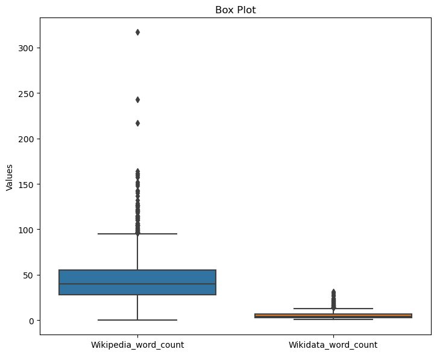

```
Visualizing Wikipedia_word_length and Wikidata_word_length
```

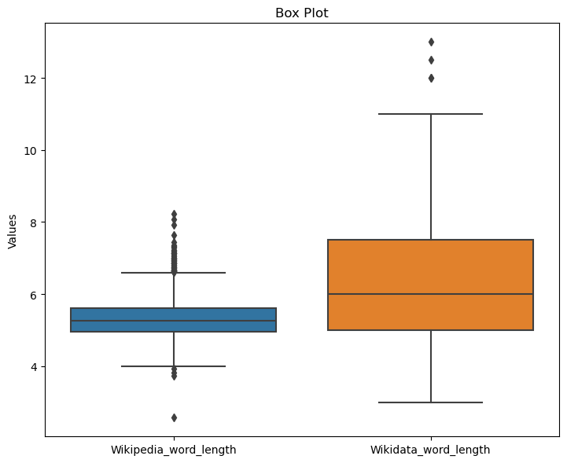

```
Visualizing Wikipedia_mean_sent_length and Wikidata_mean_sent_length
```

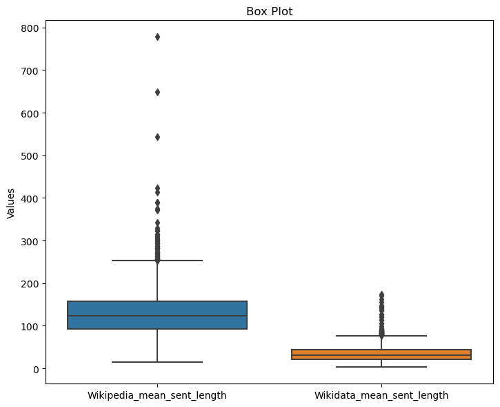

```python
features = df.columns.tolist()[5:]

# Assuming the features are ordered consistently in pairs (Wikipedia followed by Wikidata)
for i in range(0, len(features), 2):
    visualize(features[i], features[i+1])
```

### Research Question 1: How does the length of descriptions and the word count differ between data obtained from Wikipedia and Wikidata, and what are the differences in the average word length and mean sentence length between the two sources?

**To address this question, we analyzed the word counts and sentence lengths of descriptions from Wikipedia and Wikidata.**

#### Summary:

```python
def visualize(col1, col2):
    print(f'Visualizing {col1} and {col2}')

    # Ensure infinite values are converted to NaNs
    df[col1] = df[col1].replace([np.inf, -np.inf], np.nan)
    df[col2] = df[col2].replace([np.inf, -np.inf], np.nan)

    plt.figure(figsize=(14, 6))

    # Histogram for col1
    plt.subplot(1, 2, 1)
    sns.histplot(df[col1].dropna(), kde=True, bins=30, color='blue')
    plt.axvline(df[col1].mean(), color='red', linestyle='--', label=f'Mean: {df[col1].mean():.2f}')
    plt.axvline(df[col1].median(), color='yellow', linestyle='-', label=f'Median: {df[col1].median():.2f}')
    plt.xlabel(col1)
    plt.ylabel('Frequency')
    plt.title(f'Histogram of {col1}')
    plt.legend()

    # Histogram for col2
    plt.subplot(1, 2, 2)
    sns.histplot(df[col2].dropna(), kde=True, bins=30, color='green')
    plt.axvline(df[col2].mean(), color='red', linestyle='--', label=f'Mean: {df[col2].mean():.2f}')
    plt.axvline(df[col2].median(), color='yellow', linestyle='-', label=f'Median: {df[col2].median():.2f}')
    plt.xlabel(col2)
    plt.ylabel('Frequency')
    plt.title(f'Histogram of {col2}')
    plt.legend()

    plt.tight_layout()
    plt.show()
```

```
Visualizing Wikipedia_word_count and Wikidata_word_count
```

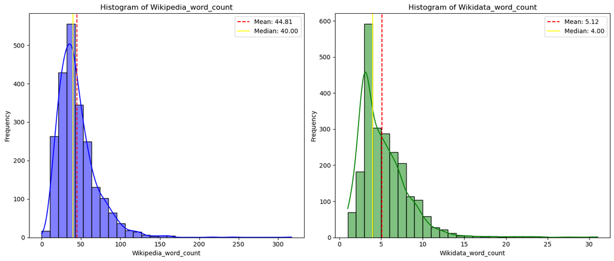

```
Visualizing Wikipedia_word_length and Wikidata_word_length
```

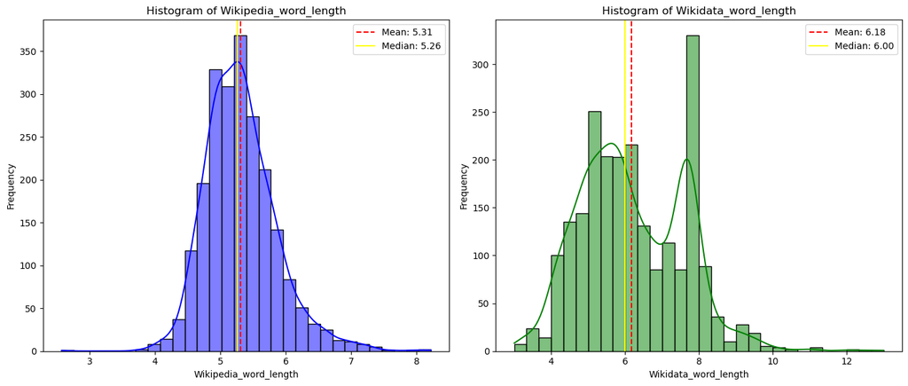

```
Visualizing Wikipedia_mean_sent_length and Wikidata_mean_sent_length
```

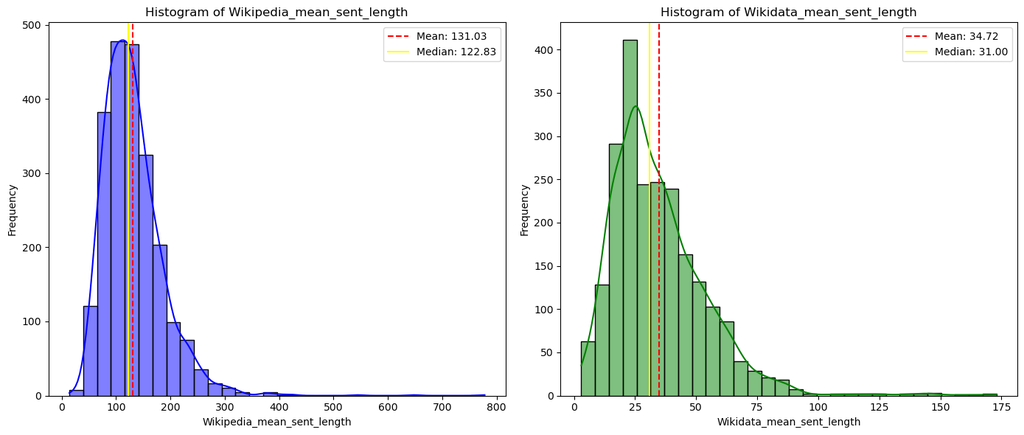

```python
features = df.columns.tolist()[5:]

# Assuming the features are ordered consistently in pairs (Wikipedia followed by Wikidata)
for i in range(0, len(features), 2):
    visualize(features[i], features[i+1])
```

### Research Question 2: How do the distributions of the lengths of descriptions, word counts, word lengths, and average sentence lengths differ between data obtained from Wikipedia and Wikidata?

To address this research question, we analyzed the distributions of description lengths, word counts, word lengths, and average sentence lengths for data obtained from Wikipedia and Wikidata.

#### Key Observations from the Histograms:

1. **Description Lengths and Word Counts**: The first set of histogram charts compares the word counts of descriptions from Wikipedia and Wikidata. Both distributions are right-skewed.
   - **Wikipedia**:
     - **Mean Word Count**: 44.81 words
     - **Median Word Count**: 40 words
     - This indicates that Wikipedia descriptions are relatively long, with a significant number of descriptions extending beyond the median length.
   - **Wikidata**:
     - **Mean Word length**: 5 words
     - **Median Word length**: 4 words
     - Wikidata descriptions are much shorter, reflecting the platform's focus on succinct, structured data.

   The stark contrast in the word counts between Wikipedia and Wikidata highlights the difference in their content structure and purpose. Wikipedia aims to provide comprehensive, detailed information, whereas Wikidata prioritizes brevity and concise data representation.
2. **Word Length**: The second set of histogram charts compares the word lengths of descriptions from Wikipedia and Wikidata.
   - **Wikipedia**:
     - **Distribution Shape**: Bell-shaped
     - **Mean Word Length**: 5.31 characters
     - **Median Word Length**: 5.26 characters
     - The bell-shaped distribution suggests that most words in Wikipedia descriptions are of moderate length, reflecting a balance between common and specialized vocabulary.
   - **Wikidata**:
     - **Distribution Shape**: Bimodal
     - **Mean Word Length**: 6.18 characters
     - **Median Word Length**: 6 characters
     - The bimodal distribution indicates two prevalent word length categories in Wikidata descriptions. This suggests a mixture of very short and relatively longer words, potentially due to the structured nature of the data which might include both brief terms and specific technical jargon.

   The significant difference in sentence lengths between the two sources underscores the varying content styles. Wikipedia's longer sentences are suited for comprehensive coverage of topics, while Wikidata's shorter sentences are optimized for concise, data-focused entries.

#### Conclusion:

The histograms reveal significant differences between Wikipedia and Wikidata in terms of description lengths, word counts, word lengths, and average sentence lengths. Wikipedia's content is characterized by longer, more detailed descriptions with higher word counts and longer sentences, making it ideal for in-depth information. In contrast, Wikidata descriptions are much shorter, with lower word counts and shorter sentences, reflecting its purpose of providing quick, concise data. Additionally, while Wikipedia's word length distribution is bell-shaped, indicating a balanced vocabulary, Wikidata's bimodal distribution highlights the presence of both very short and relatively longer words.

These insights underscore the distinct roles that Wikipedia and Wikidata play in the information ecosystem, catering to different user needs and preferences.

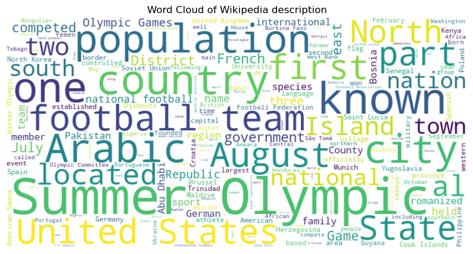

```python
from wordcloud import WordCloud
import matplotlib.pyplot as plt

# Combine 'FirstTwoSentences' from all rows into a single text
text = ' '.join(df['FirstTwoSentences'])

# Create the WordCloud object
wordcloud = WordCloud(width=800, height=400, background_color='white').generate(text)

# Display the WordCloud
plt.figure(figsize=(10, 6))
plt.imshow(wordcloud, interpolation='bilinear')
plt.title('Word Cloud of Wikipedia description')
plt.axis('off')  # Hide axis
plt.show()
```

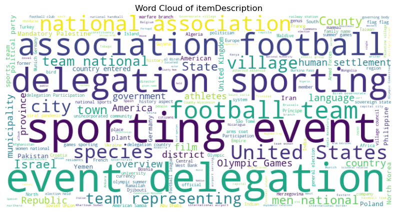

```python
# Combine 'FirstTwoSentences' from all rows into a single text
text = ' '.join(df['itemDescription'])

# Create the WordCloud object
wordcloud = WordCloud(width=800, height=400, background_color='white').generate(text)

# Display the WordCloud
plt.figure(figsize=(10, 6))
plt.imshow(wordcloud, interpolation='bilinear')
plt.title('Word Cloud of itemDescription')
plt.axis('off')  # Hide axis
plt.show()
```

**Research Question 3:**

- What are the most frequent words or phrases present in the Wikiepdia description across all rows of the dataset?
- What are the most frequent words or phrases present in the Wikidata description across all rows of the dataset?

### **5.2:** Reflection

If I had more time to complete the project, I would focus on addressing data quality issues such as missing values and inconsistencies in entity labeling. Additionally, I would delve deeper into exploring the structural aspects of the dataset, ensuring proper normalization and standardization of features. Furthermore, I would expand my research to explore more nuanced research questions, such as the impact of entity context on downstream NLP tasks and the effectiveness of different disambiguation algorithms in real-world scenarios. Finally, I would consider incorporating additional data sources and refining data collection methodologies to enhance the depth and breadth of the dataset.